# Predicción de niveles de radiación solar

### © Luis Antonio Correa Leyva

## Descripción del conjunto de datos y objetivos del proyecto

Se cuenta con un conjunto de datos de estaciones meteorológicas, en cada registro tenemos los siguentes campos:

- `estacionid`: Identificador para la estación que realizó el registro.
- `fecha` : Fecha y hora que se realizó el registro dado en el formato `YYYY-MM-DD HH-MM-SS`.
- `lat`: Latitud geográfica de la estación que realizó el registro.
- `lon`: Longitud geográfica de la estación que realizó el registro.
- `tamb`: Temperatura registrada en ese momento por la estación.
- `hum`: Nivel de humeda registrado en ese momento por la estación.
- `pres`: Presión atmosférica registrada en ese momento por la estación.
- `prec`: Desconocido.
- `rad`: Nivel de radiación solar registrado en ese momento por la estación.
- `vvien`: Velocidad del viento registrada en ese momento por la estación.
- `tipodered`: Desconocido, no relevante.

El objetivo que se persigue es poder predecir el nivel de radiación en varios momentos determinados dado que se conocen los registros de momentos anteriores. En una definición más formal el objetivo es predecir los niveles de radiación para instantes de tiempo $[t_1,t_2,...,t_n]$ dado que se conocen los registros de los instantes de tiempo $[t_{m}, t_{m+1}, ..., t_0]$ anteriores al momento $t_1$.

Para lograr este objetivo se propone emplear algoritmos de aprendizaje automático, para ser más exacto redes neuronales recurrentes, debido a que estos han demostrado en los últimos años tener un alto nivel de eficiencia y las redes neuronales recurrentes han sido diseñadas específicamente para el análisis y predicción de series temporales.

# I. Analisis de los datos

Dado que conocemos que cada registro del conjunto de datos contiene un campo para la `fecha` y que el objetivo que se persigue está relacionado con realizar predicciónes las cuáles deben estar ordenadas en el tiempo procederemos a realizar la carga de nuestros datos tomando como índice el campo `fecha` y ordenándolos en orden ascendente.

```python
from google.colab import drive
drive.mount('/content/drive')
```

```python
import pandas as pd
```

```python
data = pd.read_csv('/content/drive/My Drive/solar-forecasting/data/meteo_galicia.csv', sep=';', parse_dates=['fecha'], decimal=',',
                 infer_datetime_format=True, low_memory=False, index_col='fecha').sort_index()
```

```python
#data = pd.read_csv('./data/meteo_galicia.csv', sep=';', parse_dates=['fecha'], decimal=',',
#                 infer_datetime_format=True, low_memory=False, index_col='fecha').sort_index()
```

```python
data
```

| fecha | estacionid | lat | lon | tamb | hum | pres | prec | rad | vvien | tipodered |
| --- | --- | --- | --- | --- | --- | --- | --- | --- | --- | --- |
| 2019-01-01 00:10:00 | 20284 | 42.4044 | -8.6730 | 5.4 | 0 | 1022.0 | 0.0 | 0.0 | 0.7 | OFICIAL |
| 2019-01-01 00:10:00 | 20233 | 42.3554 | -7.0086 | 7.3 | 0 | 892.1 | 0.0 | 0.0 | 3.5 | OFICIAL |
| 2019-01-01 00:10:00 | 20218 | 43.1626 | -7.2826 | 9.2 | 0 | 955.0 | 0.0 | 0.0 | 0.0 | OFICIAL |
| 2019-01-01 00:10:00 | 20217 | 42.7071 | -7.0471 | 8.5 | 0 | 882.5 | 0.0 | 1.0 | 6.3 | OFICIAL |
| 2019-01-01 00:10:00 | 20221 | 43.5407 | -7.0830 | 5.3 | 0 | 1027.0 | 0.0 | 0.0 | 2.8 | OFICIAL |
| ... | ... | ... | ... | ... | ... | ... | ... | ... | ... | ... |
| 2019-06-01 19:40:00 | 20249 | 42.2987 | -7.5907 | 25.0 | 0 | 909.0 | 0.0 | 402.0 | 2.0 | OFICIAL |
| 2019-06-01 19:40:00 | 20259 | 42.1630 | -7.0896 | 27.0 | 0 | 922.0 | 0.0 | 374.0 | 3.0 | OFICIAL |
| 2019-06-01 19:40:00 | 20255 | 42.4631 | -6.9295 | 30.0 | 0 | NaN | 0.0 | 378.0 | 0.0 | OFICIAL |
| 2019-06-01 19:40:00 | 20187 | 42.8760 | -8.5594 | 28.0 | 0 | 988.0 | 0.0 | 419.0 | 3.0 | OFICIAL |
| 2019-06-01 19:40:00 | 20295 | 42.0786 | -8.6794 | 25.0 | 0 | 963.0 | 0.0 | 26.0 | 0.0 | OFICIAL |

2510008 rows × 10 columns

## Descripción de los datos

```python
data.describe()
```

|  | estacionid | lat | lon | tamb | hum | pres | prec | rad | vvien |
| --- | --- | --- | --- | --- | --- | --- | --- | --- | --- |
| count | 2.510008e+06 | 2.510008e+06 | 2.510008e+06 | 2.507533e+06 | 2510008.0 | 1.814653e+06 | 2.509794e+06 | 2.499161e+06 | 2.507539e+06 |
| mean | 2.023039e+04 | 4.266182e+01 | -8.022871e+00 | 8.994252e+00 | 0.0 | 9.677706e+02 | 6.805140e-03 | 1.167266e+02 | 2.144441e+00 |
| std | 4.163865e+01 | 4.825840e-01 | 6.507180e-01 | 5.504882e+00 | 0.0 | 4.522947e+01 | 2.574166e-01 | 2.210808e+02 | 3.068800e+00 |
| min | 2.015800e+04 | 4.189820e+01 | -9.178300e+00 | -2.800000e+01 | 0.0 | 7.000000e+02 | 0.000000e+00 | 0.000000e+00 | 0.000000e+00 |
| 25% | 2.019500e+04 | 4.231240e+01 | -8.644000e+00 | 5.000000e+00 | 0.0 | 9.430000e+02 | 0.000000e+00 | 0.000000e+00 | 0.000000e+00 |
| 50% | 2.023100e+04 | 4.255520e+01 | -8.066800e+00 | 9.000000e+00 | 0.0 | 9.750000e+02 | 0.000000e+00 | 0.000000e+00 | 1.000000e+00 |
| 75% | 2.026600e+04 | 4.303590e+01 | -7.439200e+00 | 1.200000e+01 | 0.0 | 1.004000e+03 | 0.000000e+00 | 1.220000e+02 | 3.000000e+00 |
| max | 2.030200e+04 | 4.373400e+01 | -6.765200e+00 | 4.800000e+01 | 0.0 | 1.061000e+03 | 1.190000e+02 | 1.265000e+03 | 1.500000e+02 |

Con esta primera observación podemos percatarnos que el campo `hum` no posee ningún dato significativo ya que en todo momento está registrado como 0, se puede asumir que los sensores de las estaciones no están registrando esta información o simplemente que el campo no es relevante para resolver el problema en cuestión. Además podemos percatarnos que la información del campo `tipodered` no posee ningún valor numérico y que aparentemente su valor permance constante por lo que tampoco aporta información util para lograr el objetivo que se desea. Se procede a eliminar los campos innecesarios.

```python
data = data.drop(columns=['tipodered', 'hum'])
```

### Las estaciones

Se conoce que cada registro se corresponde con una estación meteorológica en un instante de tiempo, y que cada estación está ubicada en un punto geográfico diferente de las demás, además se conoce que los niveles de radiación que es la variable que se quiere predecir varían en dependencia de la ubicacion geográfica. Por tanto sería de utilidad agrupar los registros por estaciones para así poder aplicar el algoritmo de aprendizaje que se determine a cada una de la estaciones por separado.

```python
estaciones = [s for s in set(data['estacionid'])]
```

```python
len(estaciones)
```

```
142
```

```python
%%time
data_by_station = []

for s in estaciones:
    filter_station = data['estacionid'] == s
    data_station = data[filter_station].drop(columns=['estacionid', 'lat', 'lon'])
    d = data_station.describe()
    if d.rad['max'] != 0:
        data_by_station.append(data_station)
```

```
CPU times: user 2.96 s, sys: 41.9 ms, total: 3 s
Wall time: 3.01 s
```

```python
len(data_by_station)
```

```
111
```

Como se observa hemos agregado un filtro extra antes de agregar los datos de cada estación a la lista `data_by_station` que contiene los registros agrupados de cada estación. Hemos especificado que solo se agreguen aquellas estación que han registrado al menos un nivel de radiación máximo diferente de cero, ya que los niveles de radiación solo toman valores positivos entonces las estaciones que registran un máximo de cero para los niveles de radiación son estaciones que no poseen información en este campo y por tanto no son de utilidad para el entrenamiento de nuestro algoritmo de aprendizaje. Como se puede ver en las instrucciónes anteriores hemos reducido la cantidad de estaciones de 142 a 111. Además hemos eliminado los campos de `estacionid`, `lat`, `lon` ya que por el momento no resultarán de utilidad para el análisis de los datos específicos de cada estación.

## Análisis gráfico

Para este análisis trabajaremos con los datos de una sola estación, podemos escoger una estación al azar de la lista pero en este caso seleccionaremos directamente la primera de la lista y asumiremos estos datos como datos de entrenamiento para la red neuronal.

```python
import matplotlib.pyplot as plt
import seaborn as sns

sns.set(rc={'figure.figsize': (16, 6)})
```

```python
data_train = data_by_station[0]
```

```python
data_train
```

| fecha | tamb | pres | prec | rad | vvien |
| --- | --- | --- | --- | --- | --- |
| 2019-01-01 01:00:00 | 11.6 | 1017.0 | 0.0 | 0.0 | 1.0 |
| 2019-01-01 01:10:00 | 10.9 | 1017.0 | 0.0 | 0.0 | 0.7 |
| 2019-01-01 01:30:00 | 10.3 | 1016.9 | 0.0 | 0.0 | 1.3 |
| 2019-01-01 01:40:00 | 10.0 | 1016.9 | 0.0 | 0.0 | 1.7 |
| 2019-01-01 02:00:00 | 10.2 | 1017.0 | 0.0 | 0.0 | 0.8 |
| ... | ... | ... | ... | ... | ... |
| 2019-06-01 18:30:00 | 27.0 | 1003.0 | 0.0 | 578.0 | 1.0 |
| 2019-06-01 18:40:00 | 26.0 | 1003.0 | 0.0 | 544.0 | 2.0 |
| 2019-06-01 19:00:00 | 26.0 | 1003.0 | 0.0 | 471.0 | 2.0 |
| 2019-06-01 19:10:00 | 25.0 | 1003.0 | 0.0 | 402.0 | 3.0 |
| 2019-06-01 19:30:00 | 21.0 | 1003.0 | 0.0 | 254.0 | 2.0 |

11573 rows × 5 columns

Si nos fijamos en nuestro índice `fecha` podemos percatarnos que el intervalo de tiempo entre registros no es constante, en algunos casos tenemos un intervalo de tiempo de 10min en otros de 20min y cabe la posibilidad de que existan otros intervalos mayores o menores. Por tanto procederemos en este caso a separar los registros por intervalos de tiempo de 10min, normalmente lo que se hace es rellenar los registros faltantes con el valor medio entre el registro anterior y posterior a este, pero en este caso estos registros son creados por estaciones meteorológicas podemos asumir que si faltan estos registros es porque en ese instante de tiempo no han ocurrido cambios con respecto al registro del instante anterior, entonces lo que haremos será rellenar estos instantes con los valores del registro anterior.

```python
data_train = data_train.resample('10T').ffill().bfill()
```

Ahora procederemos a analizar correlación entre la variable correspondiente a los niveles de radiación (`rad`) y el resto de las variables. Debido a que nuestras variables se encuentran en unidades de medida diferentes con escala diferente procederemos a normalizarlas antes de mostrar graficamente sus valores en el tiempo.

```python
def normalize(data, key):
    return (data[key] - data[key].min()) / (data[key].max() - data[key].min())
```

```python
rad = normalize(data_train, 'rad')
tamb = normalize(data_train, 'tamb')
pres = normalize(data_train, 'pres')
prec = normalize(data_train, 'prec')
vvien = normalize(data_train, 'vvien')
```

#### Relación gráfica entre Nivel de Radiación y Temperatura

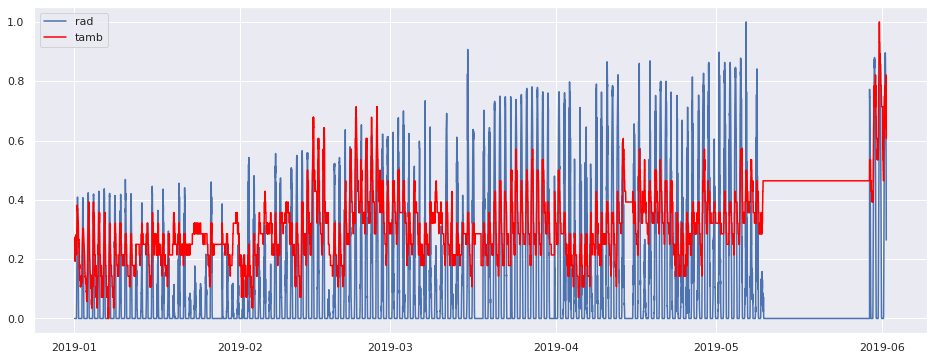

```python
plt.plot(rad, label='rad')
plt.plot(tamb, label='tamb', color='red')
plt.legend()
plt.show()
```

#### Relación gráfica entre Nivel de Radiación y Presión

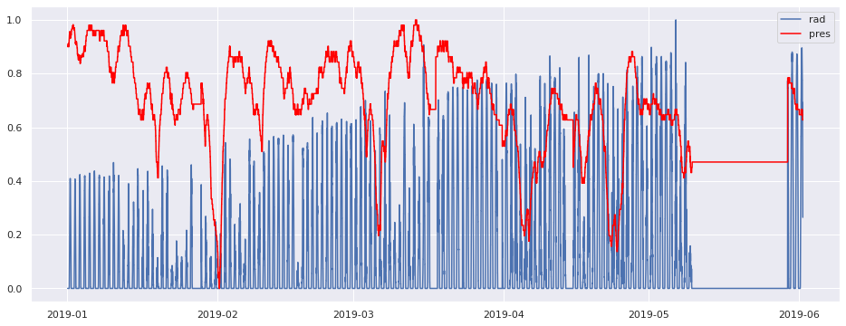

```python
plt.plot(rad, label='rad')
plt.plot(pres, label='pres', color='red')
plt.legend()
plt.show()
```

#### Relación gráfica entre Nivel de Radiación y Prec (Desconocido)

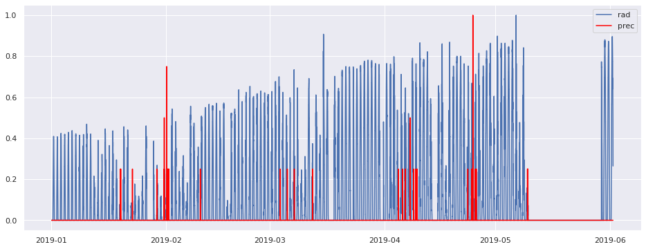

```python
plt.plot(rad, label='rad')
plt.plot(prec, label='prec', color='red')
plt.legend()
plt.show()
```

#### Relación gráfica entre Nivel de Radiación y Velocidad del viento

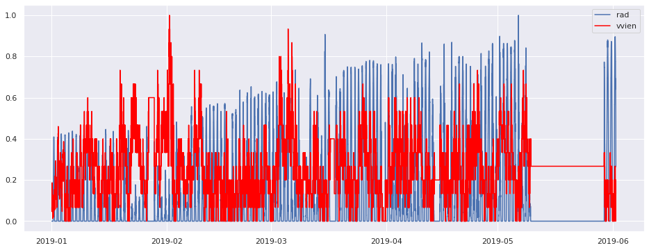

```python
plt.plot(rad, label='rad')
plt.plot(vvien, label='vvien', color='red')
plt.legend()
plt.show()
```

Estos gráficos nos muestran el comportamiento de las variables en el tiempo y nos da una intuición de si existe relación entre las variables valorando la similitud entre los gráficos, sin embargo un método más eficiente puede ser utilizar funiones matemáticas para obtener numericamente el nivel de correlación entre las variables. Para este caso utilizaremos el método de correlación de `spearman`

```python
print([i for i in range(0, len(data_train.columns))])
print([c for c in data_train.columns])
```

```
[0, 1, 2, 3, 4]
['tamb', 'pres', 'prec', 'rad', 'vvien']
```

```python
data_train.corr(method='spearman')
```

|  | tamb | pres | prec | rad | vvien |
| --- | --- | --- | --- | --- | --- |
| tamb | 1.000000 | -0.283707 | -0.025503 | 0.262111 | 0.035014 |
| pres | -0.283707 | 1.000000 | -0.069145 | 0.111469 | -0.350531 |
| prec | -0.025503 | -0.069145 | 1.000000 | 0.003748 | 0.042201 |
| rad | 0.262111 | 0.111469 | 0.003748 | 1.000000 | 0.032882 |
| vvien | 0.035014 | -0.350531 | 0.042201 | 0.032882 | 1.000000 |

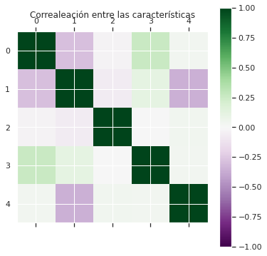

```python
plt.matshow(data_train.corr(method='spearman'),vmax=1,vmin=-1,cmap='PRGn')
plt.title('Correaleación entre las características')
plt.colorbar()
plt.show()
```

Podemos observar en el gráfico anterior que existe un nivel de correlación aproximado de 0.26 entre la radiación y la temperatura y de 0.11 entre la radiación y la presión. Para el resto de las variables podemos asumir que el nivel de correlación es muy bajo y que realmente no aportan información útil para realizar las predicciónes de los niveles de radiación. Por tanto utilizaremos como variables extras para la predicción de los niveles de radiación `tamb` y `pres`, y procedemos a eliminar del conjunto de datos el resto de la variables.

También podemos observar en los gráficos de las series temporales que entre el mes de mayo y junio existe un comportamiento lineal lo cual puede significar que durante este período no se realizaron registros del las variables. Procederemos a identificar eliminar este intervalo de tiempo lineal del conjunto de datos.

```python
data_train = data_train.drop(columns=['prec', 'vvien'])
```

```python
data_train
```

| fecha | tamb | pres | rad |
| --- | --- | --- | --- |
| 2019-01-01 01:00:00 | 11.6 | 1017.0 | 0.0 |
| 2019-01-01 01:10:00 | 10.9 | 1017.0 | 0.0 |
| 2019-01-01 01:20:00 | 10.9 | 1017.0 | 0.0 |
| 2019-01-01 01:30:00 | 10.3 | 1016.9 | 0.0 |
| 2019-01-01 01:40:00 | 10.0 | 1016.9 | 0.0 |
| ... | ... | ... | ... |
| 2019-06-01 18:50:00 | 26.0 | 1003.0 | 544.0 |
| 2019-06-01 19:00:00 | 26.0 | 1003.0 | 471.0 |
| 2019-06-01 19:10:00 | 25.0 | 1003.0 | 402.0 |
| 2019-06-01 19:20:00 | 25.0 | 1003.0 | 402.0 |
| 2019-06-01 19:30:00 | 21.0 | 1003.0 | 254.0 |

21856 rows × 3 columns

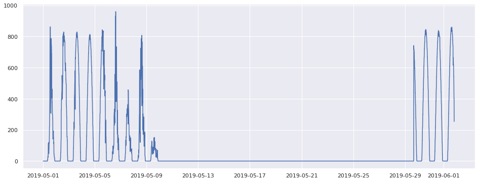

```python
plt.plot(data_train.loc['2019-05-01':]['rad'])
plt.show()
```

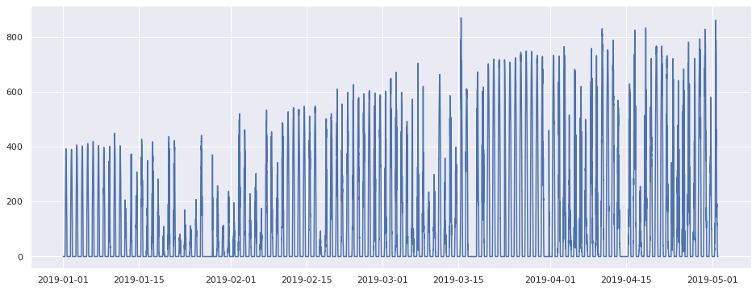

```python
data_train = data_train.loc[:'2019-05-01']

plt.plot(data_train['rad'])
plt.show()
```

# II Preparación del conjunto de datos para el entrenamiento de una red neuronal recurrente.

```python
import numpy as np
```

```python
def get_rnn_data(dataset, history_size=30, target_size=7):
    start_index = history_size
    end_index = len(dataset) - target_size

    data = []
    labels = []

    for i in range(start_index, end_index):
        indices = range(i - history_size, i, 1)
        data.append(dataset[indices])
        labels.append(dataset[i:i+target_size, -1])

    data = np.array(data)
    labels = np.array(labels)

    return data, labels
```

```python
one_day_min = 24*60

interval_min = 10
past_day = 7
forecast_day = 1

past_history = int((one_day_min / interval_min) * past_day)
forecast_horizon = int((one_day_min / interval_min) * forecast_day)

print("Past history {0} , {1} day".format(past_history, past_day))
print("Forecast horizon {0} , {1} day".format(forecast_horizon, forecast_day))
```

```
Past history 1008 , 7 day
Forecast horizon 144 , 1 day
```

Comenzaremos por entrenar un modelo que recibirá como entrada los registros de 7 días para predecir los niveles de radiación del día siguiente. Las funciones anteriores son las encargadas de tomar nuestro conjunto de datos y redimensionarlo de la manera apropiada para que sea procesado por nuestra RNN.

Con las siguientes instrucciones procedemos a normalizar nuestros datos lo cuál agiliza el proceso de aprendizaje de la red.

```python
class Scaler:
    def fit(self, data):
        self._min = data.min()
        self._max = data.max()

    def normalize(self, data):
        return (data - self._min) / (self._max - self._min)

    def denormalize(self, data):
        return data*(self._max-self._min)+self._min
```

```python
### TRAIN
tamb_scaler = Scaler()
tamb_scaler.fit(data_train['tamb'])

pres_scaler = Scaler()
pres_scaler.fit(data_train['pres'])

rad_scaler = Scaler()
rad_scaler.fit(data_train['rad'])
```

```python
data_train = data_train.values
```

```python
data_train[:, 0] = tamb_scaler.normalize(data_train[:, 0])
data_train[:, 1] = pres_scaler.normalize(data_train[:, 1])
data_train[:, 2] = rad_scaler.normalize(data_train[:, 2])
```

Con estas instrucciones tenmos listo el conjunto de datos de la estación que utilizaremos para el entrenamiento, seleccionaremos ademas otra estación para utilizarla como dataset de testing.

```python
data_test = data_by_station[1]
data_test = data_test.resample('10T').ffill().bfill()
data_test = data_test.drop(columns=['prec', 'vvien'])
data_test = data_test.loc[:'2019-05-01']

## TEST
tamb_scaler_t = Scaler()
tamb_scaler_t.fit(data_test['tamb'])

pres_scaler_t = Scaler()
pres_scaler_t.fit(data_test['pres'])

rad_scaler_t = Scaler()
rad_scaler_t.fit(data_test['rad'])

data_test = data_test.values

data_test[:, 0] = tamb_scaler_t.normalize(data_test[:, 0])
data_test[:, 1] = pres_scaler_t.normalize(data_test[:, 1])
data_test[:, 2] = rad_scaler_t.normalize(data_test[:, 2])
```

Procedemos a preparar el dataset para entrenar una RNN.

```python
%%time
data, labels = get_rnn_data(data_train, history_size=past_history, target_size=forecast_horizon)
data_test, labels_test = get_rnn_data(data_test, history_size=past_history, target_size=forecast_horizon)
```

```
CPU times: user 4.96 s, sys: 523 ms, total: 5.49 s
Wall time: 5.5 s
```

```python
data.shape
```

```
(16266, 1008, 3)
```

```python
labels.shape
```

```
(16266, 144)
```

¿Que significan estas dimensiones? Cada ejemplo de nuestro conjunto de datos contendra 1008 registros con intervalos de 10 min entre ellos, el equivalente a 7 días, cada uno de ellos con 3 características que recibirá el modelo y se le entrenará para retornar 144 registros con intervalos de 10 min cada uno equivalente a 1 día, cada uno de ellos con una sola característica que será el nivel de radiación.

```python
def plot_result(x, y, y_pred=None):
    fig, ax = plt.subplots(1, 1, figsize=(15,5))
    ax.plot(x[:,-1], 'o-', c='steelblue', ms=3.5, label='History')

    ri = range(x.shape[0], x.shape[0]+y.shape[0])
    y_index = [i for i in ri]

    ax.plot(y_index, y, 'x-', c='mediumseagreen', ms=3.5, label='Target')

    if y_pred is not None:
        ax.plot(y_index, y_pred, 'o-', c='salmon', ms=3.5, label='Predict')

    ax.legend()
```

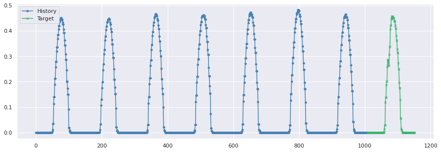

```python
plot_result(data[0], labels[0])
```

Esta función será utilizada posteriormente para mostrar de manera visual los resultados obtenidos.

# III Construcción del modelo

Como es conocido la construcción de un modelo de redes neuronales es considerado un arte, no exite una metodología capaz de decirnos exactamente como debe ser la arquitectura de nuestros modelos. Lo que podemos realizar es probar distintas configuraciones después de habernos alimentado con el conocimiento y experiencia de otros científicos que han trabajado en proyetos similares, posteriormente evaluar los resultados obtenidos y usar una mezcla entre intuición, razonamiento lógico, y experiencia obtenida de los fallos para buscar el modelo que mejor se ajuste al problema que deseamos resolver.

**NOTA:** El modelo expuesto en este Notebook y los parámetros prefijados en el texto anterior son resultado de numerosas pruebas que se realizaron con anterioridad. Este Notebook solo expone los últimos cambios que se han realizado con el objetivo de encontrar la arquitectura correcta para resolver el problema en cuestión. Los modelos han sido entrenados utilizando Google Colab con GPU para agilizar el proceso ya que son modelos que tienden a tener muchos parámetros y consumir muchos recursos y tiempo de entrenamiento.

```python
from tensorflow.keras.models import Sequential
from tensorflow.keras.layers import GRU, Dense
from tensorflow.keras.losses import mae
```

### GRU

```python
model = Sequential([
    GRU(300, input_shape=(data.shape[1], data.shape[2])),
    Dense(forecast_horizon)
])

model.compile(loss='mae', optimizer='adam')

model.summary()
```

```
Model: "sequential"
_________________________________________________________________
Layer (type)                 Output Shape              Param #
=================================================================
gru (GRU)                    (None, 300)               274500
_________________________________________________________________
dense (Dense)                (None, 144)               43344
=================================================================
Total params: 317,844
Trainable params: 317,844
Non-trainable params: 0
_________________________________________________________________
```

```python
%%time
history = model.fit(data, labels, epochs=20, batch_size=64, validation_split=0.1)
```

```
CPU times: user 4min 35s, sys: 1min 2s, total: 5min 37s
Wall time: 6min 46s
```

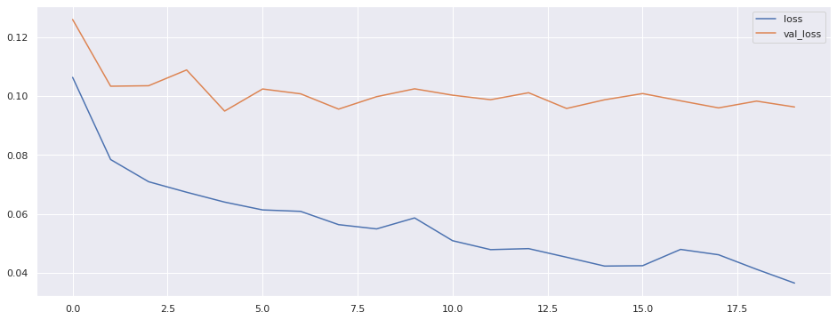

```python
plt.plot(history.history['loss'], label='loss')
plt.plot(history.history['val_loss'], label='val_loss')
plt.legend()
plt.show()
```

```python
%%time
y_pred = model.predict(data_test)
```

```
CPU times: user 7.8 s, sys: 260 ms, total: 8.06 s
Wall time: 10.6 s
```

```
MAE: 83.5160903930664
```

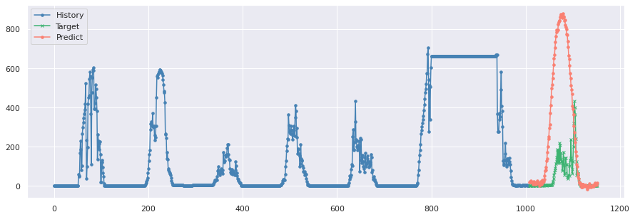

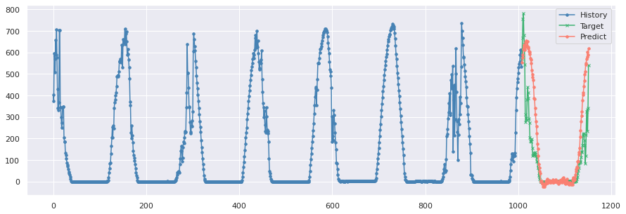

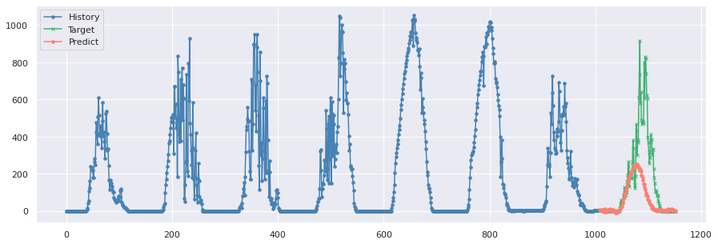

```python
yp = rad_scaler_t.denormalize(y_pred)
y = rad_scaler_t.denormalize(labels_test)
x = rad_scaler_t.denormalize(data_test)

error = np.mean(mae(y, yp))

print("MAE: {}".format(error))

for _ in range(3):
    i = np.random.randint(len(data_test))
    plot_result(x[i], y[i], yp[i])
```